# R in RStudio

# Connect to RStudio

[RStudio](https://rstudio.cluster.france-bioinformatique.fr) is a graphical interface designed for R programming language. Let us connect to RStudio and then, we will explore its content.

## IFB web RStudio

Clikc → https://rstudio.cluster.france-bioinformatique.fr

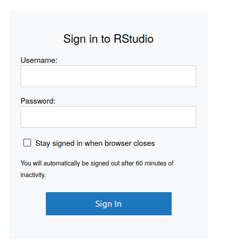

Enter the user name and password, then sign-in !

This is a RStudio web sever hosted by [French Institute of Bioinformatics](https://www.france-bioinformatique.fr/en/home/). You cannot install anything there, your work is stored there (in France), and must be declared as a research project to the IFB.

## IFB Jupyter lab

Click → [https://jupyterhub.cluster.france-bioinformatique.fr/hub/](https://jupyterhub.cluster.france-bioinformatique.fr/hub/login)

Enter the user name and password, then sign-in !

[figure not shown]

In [Jupyterlab](https://jupyter.org/), you can do more than R, but we won’t cover it on this session. Just click on RStudio button and enjoy. This is a RStudio web sever hosted by [French Institute of Bioinformatics](https://www.france-bioinformatique.fr/en/home/). You cannot install anything there, your work is stored there (in France), and must be declared as a research project to the IFB.

## Use your own RStudio server

Open your favorite terminal, and simply write:

```bash
rstudio
```

And that’s all. This is you local RStudio. No one can easily access it, so it will be more difficult to share your work. You also rely on your (small) computer rather than a big computing cluster. However, you can install anything you want.

# Rstudio

## First sight

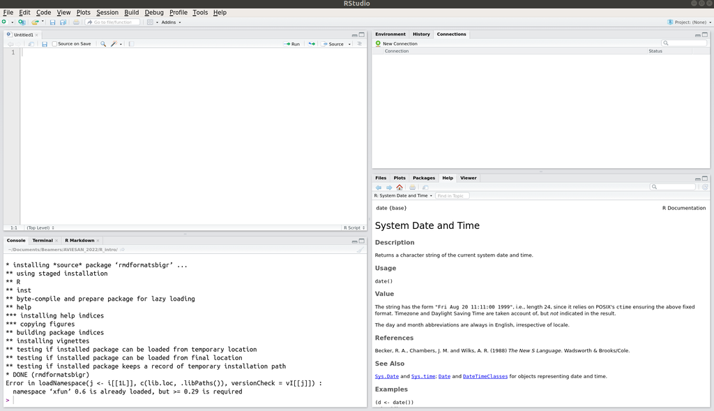

Studio displays 4 large panes. Their position may be changed based on your preference. Here are mines:

Pane names and postions

|  | left | right |
| --- | --- | --- |
| upper | Script pane | Environment/History pane |
| lower | Console pane | Help/Files |

> Info: your foud panes may be blank while two of mines are filled with text. We’ll come on that later.

## The console pane (lower left)

This is a simple R console. Open your bash terminal, enter the following command: `R`, and you will get the same console.

> Warning: Here, we are in a RStudio session powered by the *IFB*. Your local RStudio might differ: the version of R, the list of available packages, etc. On *your* local machine, RStudio console will match with the R available in *your* terminal.

Let’s try to enter the command [`print()`](https://www.rdocumentation.org/packages/base/versions/3.6.2/topics/print):

```r
print("Hello World")
```

```
[1] "Hello World"
```

We just used a *function*, called [`print`](https://www.rdocumentation.org/packages/base/versions/3.6.2/topics/print). This function tries to print on screen everything provided between parenthesis `(` and `)`. In this particular case, we gave the character string `"Hello World"`, and the function `print` successfully printed it on screen !

Now click on **Session** -> **Save Workspace as** and save the current work space. What append in the R console pane? You saw it! A command has been automatically written. For me, it is:

```r
save.image("./SingleCell.RData")
```

When you need help with R, whether on a function error, on a script result or anything alike, please save your work space and send-it to your favorite R-developer. This contains everything you did in your session.

> Info: There is a **syntax coloration**, there is a good **autocompletion** and parameter suggestion. *If I ever see anyone writing down a complete command without typing the tabulation key, then I’ll have to steal their dessert. And I’m always hungry enough for desserts.*

## The environment/history pane (upper right)

### Environment

This pane has three tabs: Environment, History and Connections.

Environment lists every single variable, object or data loaded in R. This includes only what you typed yourself and does not include environment variables. Example; in you console pane, enter the following command:

```r
zero <- 0;  # May also be written zero = 0
```

What append in the Environment pane ? You’re right: a variable is now available!

[figure not shown]

When a more complex object is declared in your work space, then some general information may be available. Example:

```r
small_table <- data.frame("col_a"=c(1, 3), "col_b"=c(2, 4));
```

You can see the dataframe. Click on it to have a preview of the data it contains, then click on the light-blue arrow have a deeper insight of its content:

[figure not shown]

Now click on **Session** -> **Clear Work space**: and see your work disappear. This action cannot be undone. While it is useful to clear one work space from time to time in order to avoid name space collisions, it is better to save your work space before.

### History

This tab is quite important: while you test and search in the console, your history keeps a track of each command line you entered. This will definitely help you to build your scripts, to pass your command lines to your coworkers, and to revert possible unfortunate errors.

Each history is related to a session. You may see many commands in your history. Some of them are not even listed in your console. R Studio in writes there every command, even the ones that were masked for the sake of your eyes (knitting commands, display commands, help commands, etc.)

Your history has a limit. This limit is set by an environment variable called `R_HISTSIZE` (standing for: R History Size). It may be checked with the function [`Sys.getenv()`](https://www.rdocumentation.org/packages/base/versions/3.6.2/topics/Sys.getenv) and set with the function [`Sys.setenv()`](https://www.rdocumentation.org/packages/base/versions/3.6.2/topics/Sys.setenv):

```r
Sys.getenv("R_HISTSIZE")
Sys.setenv(R_HISTSIZE = new_number)
```

## The help/plot/file pane

### Help

This is maybe the most important pane of your R Studio. THIS is the difference between R Studio and another code editor. Search for any function **here** and not on the internet. This pane shows you the available help for YOUR version of R, YOUR version of a given package.

Concurrent version might have both different default parameters and different interfaces. Please be sure over the internet, to copy and type commands that are not harmfull for your computer.

> Never ever copy code from the internet right to your terminal. Why? Example: https://www.wizer-training.com/blog/copy-paste

### File

Just like any file explorer, we can move accross directories, create folders and file, delete them, etc.

[figure not shown]

Or use the function [`dir.create()`](https://www.rdocumentation.org/packages/base/versions/3.6.2/topics/files2):

```r
dir.create("Intro_R")
```

You should change your working directory right now:

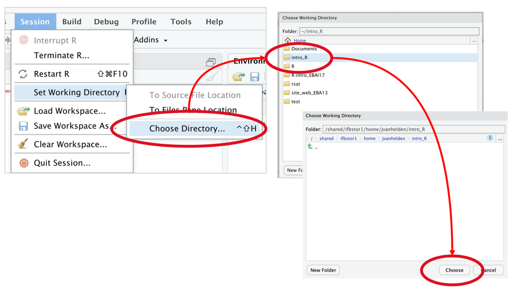

Or use [`setwd()`](https://www.rdocumentation.org/packages/base/versions/3.6.2/topics/getwd):

```r
setwd("Intro_R")
```

You can send data *from* your computer *to* a distant RStudio (e.g. on the IFB):

[figure not shown]

You can delete files:

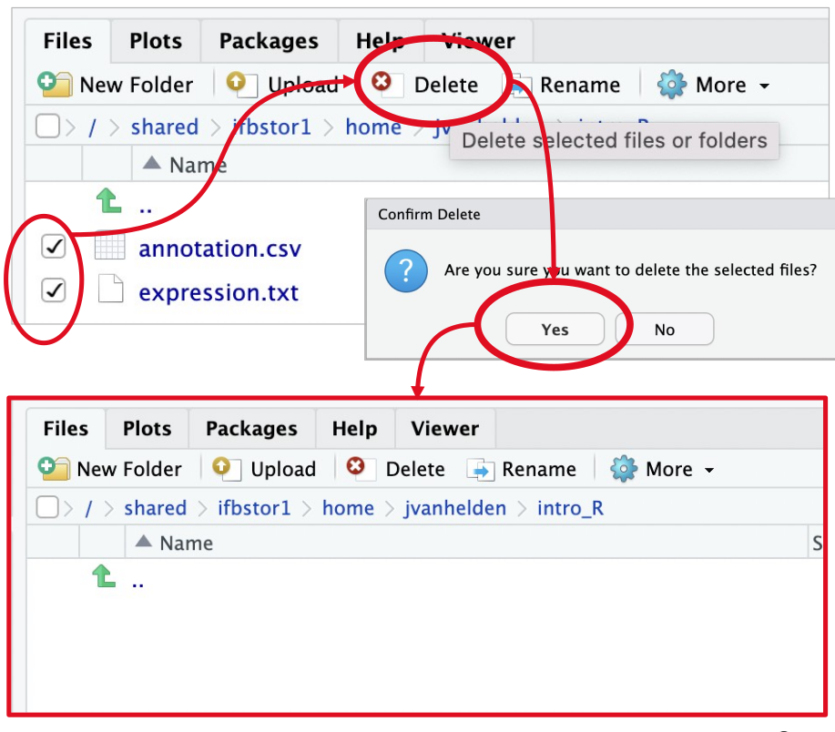

or use the function [`file.remove()`](https://www.rdocumentation.org/packages/base/versions/3.6.2/topics/files):

```r
file.remove("example.txt")
```

## The script pane (upper left)

This is where you write your R scripts. This also accepts other languages (e.g. *bash*, *python*, …), but R Studio shines for its R integration.

Please, please ! Write your commands in the Script pane, then execute them by hitting CTRL + Enter. This is very much like your lab-workbook: the history panel only keeps a limited number of function in memory while this script keeps your commands in a file on your disk. You may share it, edit it, comment it, etc.

[figure not shown]

## TLDR – Too Long Didn’t Read

Graphic interface presentation :

1. Write command lines in Script pane (upper left)
2. Execute command lines by hitting CTRL + Enter from script pane et see them in the console.
3. Have a look at the environment and history in case on the upper right pane
4. Search for help in the lower right pane.

# R – Basics

## Variables and types

### Numbers

Remember, a variable is the name given to a value stored in memory. Example `3`, the number three, exists in R. You can store it in a variable with the arrow operator `<-`:

```r
three <- 3
```

With the code above, the number 3 is stored in a variable called “three”. You can do this in R with anything. Literally anything. Whole files, pipelines, images, anything.

Maths in R works the same as your regular calculator:

```r
3 + three # Add
```

```
[1] 6
```

```r
1 - 2 # Subtract
```

```
[1] -1
```

```r
4 / 2 # Divide
```

```
[1] 2
```

```r
3 * 4 # Multiply
```

```
[1] 12
```

```r
7 %/% 2 # Floor division
```

```
[1] 3
```

### Characters

Characters are delimited with quotes: either double `"` or `'` simple:

```r
four <- "4"
five <- '5'

# The example below is a very good example of
# how to never ever name a variable.
シ <- "happy"
```

Mathematics do not work with characters at all … Try the following:

```r
"4" + 1
four + 1
```

You can try to turn characters in numbers with the function: [`as.numeric`](https://www.rdocumentation.org/packages/h2o/versions/3.38.0.1/topics/as.numeric):

```r
as.numeric("4") + 1
```

```
[1] 5
```

```r
as.numeric(four) + 1
```

```
[1] 5
```

A *function* is a R command that is followed by parenthesis `(` and `)`. Between these parenthesis, we enter *arguments*. Use the help pane to have information about the list of arguments expected and/or understood by a given function.

As said previously, you can store any of the previously typed commands in a variable:

```r
five <- as.numeric("4") + 1
two <- 1 + (0.5 * 2)
print(five)
```

```
[1] 5
```

```r
print(two)
```

```
[1] 2
```

> Please! Please! Give your variable a name understandable by humans. I don’t want to see any of you calling their variable “a”, “b”, my_var”, …

**Tricky Question:**

I have two numbers: `mysterious_number_7`, and `suspicious_number_7`. When I apply the function [`print`](https://www.rdocumentation.org/packages/base/versions/3.6.2/topics/print) on them, it return `7`. They are both numeric. However, they are not equal … Why ?

```r
# Show the value of the variable mysterious_number_7
print(mysterious_number_7)
```

```
[1] 7
```

```r
# Show the value of the number suspicious_number_7
print(suspicious_number_7)
```

```
[1] 7
```

```r
# Check that mysterious_number_7 is a number
is.numeric(mysterious_number_7)
```

```
[1] TRUE
```

```r
# Check that suspicious_number_7 is a number
is.numeric(suspicious_number_7)
```

```
[1] TRUE
```

```r
# Check that values of mysterious_number_7 and suspicious_number_7 are equal
mysterious_number_7 == suspicious_number_7
```

```
[1] FALSE
```

```r
# Check that values of mysterious_number_7 and suspicious_number_7 are identical
identical(mysterious_number_7, suspicious_number_7)
```

```
[1] FALSE
```

We will talk about difference between equality and identity later.

**Answer**

This is due to the number of digits displayed in R. You are very likely to have issues with that in the future, as all (bio)informatician around the world.

```r
mysterious_number_7 <- 7.0000001
suspicious_number_7 <- 7
print(mysterious_number_7)
```

```
[1] 7
```

```r
print(suspicious_number_7)
```

```
[1] 7
```

```r
mysterious_number_7 == suspicious_number_7
```

```
[1] FALSE
```

```r
identical(mysterious_number_7, suspicious_number_7)
```

```
[1] FALSE
```

You can change the number of displayed digits with the function [`options()`](https://www.rdocumentation.org/packages/base/versions/3.6.2/topics/options): `options(digits=100)`

### Boolean

Aside from characters and numeric, there is another very important type in R (and computer science in general): *booleans*. There are two booleans: `TRUE` and `FALSE`.

```r
3 > 4
```

```
[1] FALSE
```

```r
10 < 2
```

```
[1] FALSE
```

## Data structures

### Vector

You can make vectors and tables in R. Don’t panic, there will be no maths in this presentation.

In R, vectors are created with the function [`c`](https://www.rdocumentation.org/packages/base/versions/3.6.2/topics/c):

```r
one2three <- c("1", "2", "3", "4", "10", "20")
print(one2three)
```

```
[1] "1"  "2"  "3"  "4"  "10" "20"
```

One can select an element of the vector with squared brackets `[` and `]`:

```r
one2three[1]
```

```
[1] "1"
```

One can select multiple elements of a vector with `:`:

```r
one2three[2:4]
```

```
[1] "2" "3" "4"
```

*Question 1*: Is there a difference between these two vectors ?

```r
c_vector <- c("1", "2", "3")
n_vector <- c( 1,   2,   3 )
```

**Answer**

There is a difference indeed: c_vector contains characters, n_vector contains numeric.

```r
print(c_vector)
```

```
[1] "1" "2" "3"
```

```r
print(n_vector)
```

```
[1] 1 2 3
```

```r
print(is.numeric(c_vector))
```

```
[1] FALSE
```

```r
print(is.numeric(n_vector))
```

```
[1] TRUE
```

```r
identical(c_vector, n_vector)
```

```
[1] FALSE
```

You can always use the function [`identical`](https://www.rdocumentation.org/packages/base/versions/3.6.2/topics/identical) to test equality with robustness and exactitude.

You may have learned about the operator `==` for equality. But this is not perfect, look at our example:

```r
c_vector == n_vector
```

```
[1] TRUE TRUE TRUE
```

The operator `==` is not aware of types.

Another example, mixing numeric and boolans:

```r
1 == TRUE
```

```
[1] TRUE
```

```r
identical(1, TRUE)
```

```
[1] FALSE
```

In computer science, there is a reason why boolean and integers are mixed. We won’t cover this reason now. It’s out of our scope. Feel free to ask if you’re interested in history and maths.

*Question 2*: Can I include both text and numbers in a vector ?

```r
mixed_vector <- c(1, "2", 3)
```

**Answer**

No. We can not mix types in a vector. Either all its content is made of number or all its content is made of characters.

Here, all our values have been turned into characters:

```r
print(mixed_vector)
```

```
[1] "1" "2" "3"
```

```r
print(is.numeric(mixed_vector))
```

```
[1] FALSE
```

```r
print(is.character(mixed_vector))
```

```
[1] TRUE
```

```r
print(all(is.numeric((mixed_vector))))
```

```
[1] FALSE
```

```r
print(all(is.character((mixed_vector))))
```

```
[1] TRUE
```

Above, the function [`all`](https://www.rdocumentation.org/packages/base/versions/3.6.2/topics/all) returns `TRUE` if all its content equals to `TRUE`.

### Data Frame

In R, tables are created with the function [`data.frame`](https://www.rdocumentation.org/packages/base/versions/3.6.2/topics/data.frame):

```r
one2three4 <- data.frame(c(1, 3), c(2, 4))
print(one2three4)
```

```
  c.1..3. c.2..4.
1       1       2
2       3       4
```

You can rename columns and row names respectively with function [`colnames`](https://www.rdocumentation.org/packages/base/versions/3.6.2/topics/row%2Bcolnames) and [`rownames`](https://www.rdocumentation.org/packages/base/versions/3.6.2/topics/row%2Bcolnames).

```r
colnames(one2three4) <- c("Col_1_3", "Col_2_4")
rownames(one2three4) <- c("Row_1_2", "Row_3_4")
print(one2three4)
```

```
        Col_1_3 Col_2_4
Row_1_2       1       2
Row_3_4       3       4
```

You can access a column and a line of the data frame using squared brackets `[` and `]`. Use the following syntax: `[row, column]`. Use either the name of the row/column or its position.

```r
# Select a row by its name
print(one2three4["Row_1_2", ])
```

```
        Col_1_3 Col_2_4
Row_1_2       1       2
```

```r
# Select a row by its index
print(one2three4[1, ])
```

```
        Col_1_3 Col_2_4
Row_1_2       1       2
```

```r
 # Select a column by its name
print(one2three4[, "Col_1_3"])
```

```
[1] 1 3
```

```r
 # Select a column by its index
print(one2three4[, 1])
```

```
[1] 1 3
```

```r
 # Select a cell in the table
print(one2three4["Row_1_2", "Col_1_3"])
```

```
[1] 1
```

```r
# Select the first two rows and the first column in the table
print(one2three4[1:2, 1])
```

```
[1] 1 3
```

> If you like maths, you will remember the order `[row, column]`. If you’re not familiar with that, then you will do like 99% of all software engineer: you will write `[column, row]`, and you will get an error. Trust me. 99%. Remember, an error is never a problem in informatics

*Question 1*: Can I mix characters and numbers in a data frame *row* ?

**Answer**

Yes, it is possible:

```r
mixed_data_frame <- data.frame(
  "Character_Column" = c("a", "b", "c"),
  "Number_Column" = c(4, 5, 6)
)
print(mixed_data_frame)
```

```
  Character_Column Number_Column
1                a             4
2                b             5
3                c             6
```

The function [`str`](https://www.rdocumentation.org/packages/utils/versions/3.6.2/topics/str) can be used to look at the types of each elements in an object.

```r
str(mixed_data_frame)
```

```
'data.frame':   3 obs. of  2 variables:
 $ Character_Column: Factor w/ 3 levels "a","b","c": 1 2 3
 $ Number_Column   : num  4 5 6
```

```r
str(one2three4)
```

```
'data.frame':   2 obs. of  2 variables:
 $ Col_1_3: num  1 3
 $ Col_2_4: num  2 4
```

*Question 1*: Can I mix characters and numbers in a data frame *column* ?

**Answer**

No:

```r
mixed_data_frame <- data.frame(
  "Mixed_letters" = c(1, "b", "c"),
  "Mixed_numbers" = c(4, "5", 6)
)
print(mixed_data_frame)
```

```
  Mixed_letters Mixed_numbers
1             1             4
2             b             5
3             c             6
```

```r
str(mixed_data_frame)
```

```
'data.frame':   3 obs. of  2 variables:
 $ Mixed_letters: Factor w/ 3 levels "1","b","c": 1 2 3
 $ Mixed_numbers: Factor w/ 3 levels "4","5","6": 1 2 3
```

### Read a table as data frame

Exercise: Use the *Help pane* to find how to use the function [`read.csv`](https://www.rdocumentation.org/packages/utils/versions/3.6.2/topics/read.table).

Use the function [`read.csv`](https://www.rdocumentation.org/packages/utils/versions/3.6.2/topics/read.table) to:

1. open the *file* `./example_table.csv`.
2. this table has a *header* (`TRUE`).
3. this table has *row names* in the column called “Gene_id”.

Let all other parameters to their default values.

Save the opened table in a *variable* called `example_table`.

**Solution**

```r
example_table <- read.csv(
  file="./example_table.csv",
  header=TRUE,
  row.names="Gene_id"
)
```

Now let us explore this dataset.

We can click on environment pane:

[figure not shown]

And if you click on it:

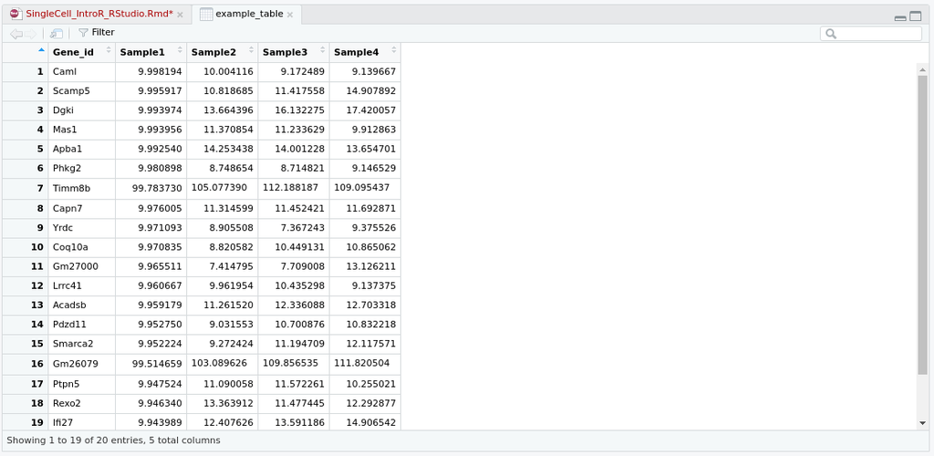

Be careful, large table may hang your session.

Alternatively, we can use the function [`head`](https://www.rdocumentation.org/packages/utils/versions/3.6.2/topics/head) which prints the first lines of a table:

```r
head(example_table)
```

```
        Sample1   Sample2   Sample3   Sample4
Caml   9.998194 10.004116  9.172489  9.139667
Scamp5 9.995917 10.818685 11.417558 14.907892
Dgki   9.993974 13.664396 16.132275 17.420057
Mas1   9.993956 11.370854 11.233629  9.912863
Apba1  9.992540 14.253438 14.001228 13.654701
Phkg2  9.980898  8.748654  8.714821  9.146529
```

The function [`summary`](https://www.rdocumentation.org/packages/base/versions/3.6.2/topics/summary) describes the dataset *per sample*:

```r
summary(example_table)
```

```
    Sample1          Sample2           Sample3           Sample4
 Min.   : 9.944   Min.   :  6.838   Min.   :  5.551   Min.   :  5.844
 1st Qu.: 9.953   1st Qu.:  9.000   1st Qu.: 10.120   1st Qu.:  9.779
 Median : 9.971   Median : 10.954   Median : 11.326   Median : 11.905
 Mean   :18.937   Mean   : 19.836   Mean   : 20.828   Mean   : 21.412
 3rd Qu.: 9.994   3rd Qu.: 12.647   3rd Qu.: 12.650   3rd Qu.: 13.968
 Max.   :99.784   Max.   :105.077   Max.   :112.188   Max.   :111.820
```

Have a look at the [`summary`](https://www.rdocumentation.org/packages/base/versions/3.6.2/topics/summary) of the dataset *per gene*, using the function [`t`](https://www.rdocumentation.org/packages/base/versions/3.6.2/topics/t) to *transpose*:

```r
head(t(example_table))
```

```
             Caml    Scamp5      Dgki      Mas1    Apba1    Phkg2    Timm8b
Sample1  9.998194  9.995917  9.993974  9.993956  9.99254 9.980898  99.78373
Sample2 10.004116 10.818685 13.664396 11.370854 14.25344 8.748654 105.07739
Sample3  9.172489 11.417558 16.132275 11.233629 14.00123 8.714821 112.18819
Sample4  9.139667 14.907892 17.420057  9.912863 13.65470 9.146529 109.09544
            Capn7     Yrdc    Coq10a   Gm27000    Lrrc41    Acadsb    Pdzd11
Sample1  9.976005 9.971093  9.970835  9.965511  9.960667  9.959179  9.952750
Sample2 11.314599 8.905508  8.820582  7.414795  9.961954 11.261520  9.031553
Sample3 11.452421 7.367243 10.449131  7.709008 10.435298 12.336088 10.700876
Sample4 11.692871 9.375526 10.865062 13.126211  9.137375 12.703318 10.832218
          Smarca2   Gm26079     Ptpn5    Rexo2     Ifi27   Snhg20
Sample1  9.952224  99.51466  9.947524  9.94634  9.943989 9.943724
Sample2  9.272424 103.08963 11.090058 13.36391 12.407626 6.838499
Sample3 11.194709 109.85654 11.572261 11.47744 13.591186 5.551247
Sample4 12.117571 111.82050 10.255021 12.29288 14.906542 5.843670
```

```r
summary(t(example_table))
```

```
      Caml            Scamp5            Dgki             Mas1
 Min.   : 9.140   Min.   : 9.996   Min.   : 9.994   Min.   : 9.913
 1st Qu.: 9.164   1st Qu.:10.613   1st Qu.:12.747   1st Qu.: 9.974
 Median : 9.585   Median :11.118   Median :14.898   Median :10.614
 Mean   : 9.579   Mean   :11.785   Mean   :14.303   Mean   :10.628
 3rd Qu.:10.000   3rd Qu.:12.290   3rd Qu.:16.454   3rd Qu.:11.268
 Max.   :10.004   Max.   :14.908   Max.   :17.420   Max.   :11.371
     Apba1            Phkg2           Timm8b           Capn7
 Min.   : 9.993   Min.   :8.715   Min.   : 99.78   Min.   : 9.976
 1st Qu.:12.739   1st Qu.:8.740   1st Qu.:103.75   1st Qu.:10.980
 Median :13.828   Median :8.948   Median :107.09   Median :11.384
 Mean   :12.975   Mean   :9.148   Mean   :106.54   Mean   :11.109
 3rd Qu.:14.064   3rd Qu.:9.355   3rd Qu.:109.87   3rd Qu.:11.513
 Max.   :14.253   Max.   :9.981   Max.   :112.19   Max.   :11.693
      Yrdc           Coq10a          Gm27000           Lrrc41
 Min.   :7.367   Min.   : 8.821   Min.   : 7.415   Min.   : 9.137
 1st Qu.:8.521   1st Qu.: 9.683   1st Qu.: 7.635   1st Qu.: 9.755
 Median :9.141   Median :10.210   Median : 8.837   Median : 9.961
 Mean   :8.905   Mean   :10.026   Mean   : 9.554   Mean   : 9.874
 3rd Qu.:9.524   3rd Qu.:10.553   3rd Qu.:10.756   3rd Qu.:10.080
 Max.   :9.971   Max.   :10.865   Max.   :13.126   Max.   :10.435
     Acadsb           Pdzd11          Smarca2          Gm26079
 Min.   : 9.959   Min.   : 9.032   Min.   : 9.272   Min.   : 99.51
 1st Qu.:10.936   1st Qu.: 9.722   1st Qu.: 9.782   1st Qu.:102.20
 Median :11.799   Median :10.327   Median :10.573   Median :106.47
 Mean   :11.565   Mean   :10.129   Mean   :10.634   Mean   :106.07
 3rd Qu.:12.428   3rd Qu.:10.734   3rd Qu.:11.425   3rd Qu.:110.35
 Max.   :12.703   Max.   :10.832   Max.   :12.118   Max.   :111.82
     Ptpn5            Rexo2            Ifi27            Snhg20
 Min.   : 9.948   Min.   : 9.946   Min.   : 9.944   Min.   :5.551
 1st Qu.:10.178   1st Qu.:11.095   1st Qu.:11.792   1st Qu.:5.771
 Median :10.673   Median :11.885   Median :12.999   Median :6.341
 Mean   :10.716   Mean   :11.770   Mean   :12.712   Mean   :7.044
 3rd Qu.:11.211   3rd Qu.:12.561   3rd Qu.:13.920   3rd Qu.:7.615
 Max.   :11.572   Max.   :13.364   Max.   :14.907   Max.   :9.944
```